# IR4

Implement Agglomerative hierarchical clustering algorithm using appropriate dataset.

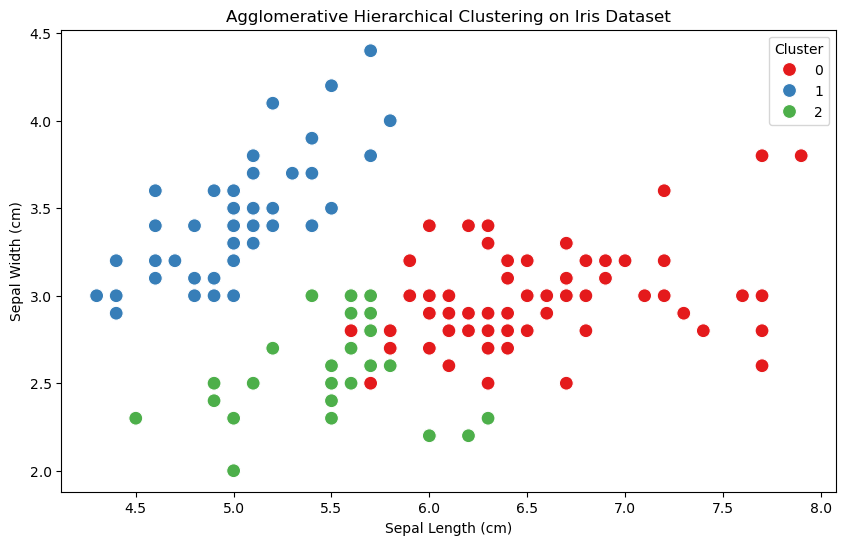

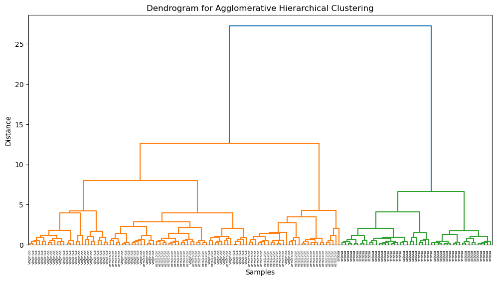

```python
import numpy as np
import pandas as pd
import matplotlib.pyplot as plt
import seaborn as sns
from sklearn.datasets import load_iris
from sklearn.cluster import AgglomerativeClustering
from scipy.cluster.hierarchy import dendrogram, linkage

# Load the Iris dataset
iris = load_iris()
X = iris.data
y = iris.target

# Convert to DataFrame for easier handling
df = pd.DataFrame(X, columns=iris.feature_names)

# Standardizing the data (optional but recommended)
from sklearn.preprocessing import StandardScaler
scaler = StandardScaler()
X_scaled = scaler.fit_transform(X)

# Perform Agglomerative Hierarchical Clustering
# Create the model with the number of clusters
model = AgglomerativeClustering(n_clusters=3)  # Change n_clusters as needed
model.fit(X_scaled)

# Add the cluster labels to the DataFrame
df['Cluster'] = model.labels_

# Plotting the clusters
plt.figure(figsize=(10, 6))
sns.scatterplot(data=df, x='sepal length (cm)', y='sepal width (cm)', hue='Cluster', palette='Set1', s=100)
plt.title('Agglomerative Hierarchical Clustering on Iris Dataset')
plt.xlabel('Sepal Length (cm)')
plt.ylabel('Sepal Width (cm)')
plt.legend(title='Cluster')
plt.show()

# Create a dendrogram
plt.figure(figsize=(12, 6))
linked = linkage(X_scaled, 'ward')
dendrogram(linked, orientation='top', labels=iris.target_names[y], distance_sort='descending', show_leaf_counts=True)
plt.title('Dendrogram for Agglomerative Hierarchical Clustering')
plt.xlabel('Samples')
plt.ylabel('Distance')
plt.show()
```

### 1. **Imports**

import numpy as np import pandas as pd import matplotlib.pyplot as plt import seaborn as sns from sklearn.datasets import load_iris from sklearn.cluster import AgglomerativeClustering from scipy.cluster.hierarchy import dendrogram, linkage

#### Explanation:

- **`import numpy as np`**:
  - **Why?** NumPy is a fundamental library for numerical computations.
- **`import pandas as pd`**:
  - **Why?** Pandas is a powerful data manipulation library used to handle data in the form of DataFrames.
- **`import matplotlib.pyplot as plt`**:
  - **Why?** Matplotlib is a plotting library. We use `pyplot` from Matplotlib to create visualizations like scatter plots and dendrograms to help interpret the clustering results.
- **`import seaborn as sns`**:
  - **Why?** Seaborn is a data visualization library built on top of Matplotlib. It provides a higher-level interface for making attractive and informative statistical graphics. Here, it's used to create a scatter plot with better aesthetics and color handling.
- **`from sklearn.datasets import load_iris`**:
  - **Why?** `load_iris` is a utility from `sklearn.datasets` that loads the Iris dataset. This dataset contains features (such as sepal length and width) of Iris flowers, which we will use for clustering.
- **`from sklearn.cluster import AgglomerativeClustering`**:
  - **Why?** This is the core algorithm you will be using for clustering. `AgglomerativeClustering` is a method of hierarchical clustering that starts with individual data points and progressively merges the closest pairs to form clusters.
- **`from scipy.cluster.hierarchy import dendrogram, linkage`**:
  - **Why?** These are functions from the `scipy.cluster.hierarchy` module:
    - `linkage`: Computes the hierarchical clustering encoded as a linkage matrix, which is required for visualizing the dendrogram.
    - `dendrogram`: This function plots a tree-like diagram (dendrogram) of the hierarchical clustering, allowing us to visually inspect the merging process of clusters.

### 2. **Loading the Iris Dataset**

iris = load_iris() X = iris.data y = iris.target

[output not shown]

#### Explanation:

- **`from sklearn.preprocessing import StandardScaler`**: `StandardScaler` is a feature scaler from `sklearn` that standardizes the data by removing the mean and scaling to unit variance.
- **`scaler = StandardScaler()`**: Here, we create an instance of the `StandardScaler` class.
- **`X_scaled = scaler.fit_transform(X)`**: This scales the feature matrix `X` to have a mean of 0 and a standard deviation of 1 for each feature.
  - **Why?** Standardizing is crucial for clustering, especially hierarchical clustering, because it is sensitive to the scale of the data. Features with larger scales could dominate the distance computation, leading to biased clustering results.

### 5. **Perform Agglomerative Hierarchical Clustering**

model = AgglomerativeClustering(n_clusters=3) model.fit(X_scaled)

[output not shown]

#### Explanation:

- **`df['Cluster'] = model.labels_`**: This adds the cluster labels computed by the clustering algorithm to the DataFrame `df` under the new column "Cluster".
  - **Why?** This allows you to see which data points were assigned to which cluster and makes it easier to visualize the clustering results.

### 7. **Plotting the Clusters**

plt.figure(figsize=(10, 6)) sns.scatterplot(data=df, x='sepal length (cm)', y='sepal width (cm)', hue='Cluster', palette='Set1', s=100) plt.title('Agglomerative Hierarchical Clustering on Iris Dataset') plt.xlabel('Sepal Length (cm)') plt.ylabel('Sepal Width (cm)') plt.legend(title='Cluster') plt.show()

[output not shown]

### Summary:

#### Key Elements:

1. **Title**:
   - **"Dendrogram for Agglomerative Hierarchical Clustering"**: Indicates the type of clustering used and the purpose of the dendrogram.
2. **X-Axis**:
   - **Samples**: Represents the individual data samples or points. Each point along the x-axis corresponds to a data sample in the dataset.
3. **Y-Axis**:
   - **Distance**: Represents the dissimilarity or distance between clusters. The height of the vertical lines indicates the distance at which clusters are joined.
4. **Horizontal Lines**:
   - These lines connect different clusters at various heights. The height of the lines shows the level of dissimilarity between the clusters being joined.
5. **Color-Coded Clusters**:
   - Different colors are used to distinguish between different clusters, making it easier to see how the data points are grouped.

### What is Clustering?

**Clustering** is an unsupervised learning technique in machine learning and data mining where the goal is to group a set of objects (or data points) into **clusters** or **groups**, such that objects within the same cluster are more similar to each other than to objects in other clusters.

#### Characteristics of Clustering:

- **Unsupervised**: Clustering does not rely on predefined labels.
- **Similarity-Based**: Data points are grouped together based on some measure of similarity, such as Euclidean distance (for continuous data), cosine similarity (for text data), etc.
- **Cluster Membership**: Each data point is assigned to exactly one cluster, but some clustering algorithms may allow the possibility of data points being assigned to multiple clusters with varying degrees of membership (fuzzy clustering).

#### Types of Clustering Algorithms:

1. **Partitional Clustering**: The dataset is divided into a set number of clusters. Examples include:
   - **K-means**: Divides data into `k` clusters by minimizing the within-cluster variance.
   - **K-medoids**: Similar to K-means but uses actual data points (medoids) as the cluster centers.
2. **Hierarchical Clustering**: Builds a tree-like structure (dendrogram) where data points are nested into clusters. This can be done in two ways:
   - **Agglomerative**: A bottom-up approach where each point starts as its own cluster, and clusters are merged iteratively.
   - **Divisive**: A top-down approach where the whole dataset is considered as one cluster, and it is divided into smaller clusters iteratively.
3. **Density-Based Clustering**: Identifies clusters based on regions of high point density in the data space. Examples:
   - **DBSCAN (Density-Based Spatial Clustering of Applications with Noise)**: Groups together closely packed points and marks points in low-density regions as outliers.
4. **Model-Based Clustering**: Assumes that the data is generated by a mixture of underlying probability distributions (such as Gaussian distributions). Example:
   - **Gaussian Mixture Models (GMM)**: A probabilistic model that assumes data is generated from a mixture of several Gaussian distributions.

### What is Hierarchical Clustering?

**Hierarchical Clustering** is a type of clustering that builds a hierarchy of clusters. hierarchical clustering doesn't require you to specify the number of clusters beforehand. Instead, it produces a **dendrogram** (a tree-like structure) that illustrates the arrangement of clusters at various levels of granularity.

#### Two Types of Hierarchical Clustering:

1. **Agglomerative Hierarchical Clustering (Bottom-Up)**:
   - **Start with individual data points**: Initially, each data point is considered its own cluster.
   - **Merge the closest clusters**: At each step, the two closest clusters are merged into one cluster.
   - **Continue merging**: This process is repeated until all data points belong to one single cluster or until a predefined number of clusters is reached.

This is the most common form of hierarchical clustering.

2. **Divisive Hierarchical Clustering (Top-Down)**:
   - **Start with all data points in one cluster**: Initially, all data points are in a single cluster.
   - **Divide the cluster**: At each step, the cluster is split into smaller subclusters.
   - **Continue dividing**: This process continues until each data point is in its own cluster or until a predefined number of clusters is achieved.

   Divisive clustering is less commonly used compared to agglomerative clustering.

### How Hierarchical Clustering Works (Agglomerative Method):

Here is a step-by-step explanation of **Agglomerative Hierarchical Clustering**, which is the most commonly used type of hierarchical clustering.

1. **Initialization**:
   - Consider each data point as its own individual cluster. For `n` data points, you start with `n` clusters.
2. **Compute Similarity**:
   - Compute the pairwise similarity or distance between all pairs of clusters (using a distance measure like Euclidean distance).
3. **Merge Closest Clusters**:
   - Identify the two closest clusters (the ones with the smallest distance between them) and merge them into a single cluster.
4. **Update the Distance Matrix**:
   - After each merge, update the distance matrix to reflect the new distances between the newly merged cluster and the other remaining clusters.
5. **Repeat**:
   - Continue merging the closest clusters and updating the distance matrix until you are left with one single cluster that contains all data points, or until a desired number of clusters is achieved.
6. **Visualize the Dendrogram**:
   - The result of hierarchical clustering can be visualized in a **dendrogram**, which is a tree-like diagram. It shows how clusters were merged at each step and the distance (dissimilarity) at which each merge happened.

### Example: Agglomerative Hierarchical Clustering

Consider an example where we have five data points:

- A, B, C, D, and E.

Initially, each of these points is a cluster of its own:

- A | B | C | D | E

The algorithm calculates the distance between every pair of clusters. Suppose the closest clusters are A and B. These two clusters are merged, and now the clusters are:

- AB | C | D | E

The algorithm will continue in the same way, merging the closest clusters until only one cluster remains.

### Dendrogram: A Visual Representation

A **dendrogram** is a tree-like diagram that visually represents the hierarchy of merges (in agglomerative clustering) or splits (in divisive clustering).

- **Leaves**: Represent individual data points.
- **Branches**: Represent the merging of clusters. The height of the branch represents the distance (or dissimilarity) between the clusters being merged.

A dendrogram helps in:

- Deciding the **number of clusters**: You can "cut" the dendrogram at a certain level to decide the desired number of clusters.
- Visualizing **cluster relationships**: It shows how data points and clusters are related at each level of the hierarchy.

For example, in agglomerative hierarchical clustering, the dendrogram shows which clusters were merged and at what level, so you can visualize which data points or clusters are similar to each other.

### Hierarchical Clustering vs. Partitional Clustering (e.g., K-Means)

1. **Hierarchical Clustering**:
   - **No need to specify number of clusters** upfront.
   - Produces a **dendrogram** which shows the entire merging process.
   - Can be computationally expensive for large datasets.
   - Works well for datasets where you want to see the hierarchical structure of clusters.
2. **Partitional Clustering** (e.g., K-Means):
   - **Requires the number of clusters (`k`)** to be specified upfront.
   - Tends to be faster and more efficient for larger datasets compared to hierarchical clustering.
   - **No hierarchical structure** is provided — only the final cluster assignments.

### Summary:

- **Clustering** is the process of grouping similar data points into clusters based on their features. It's an unsupervised learning technique where there is no labeled data.
- **Hierarchical Clustering** is a type of clustering that builds a tree-like structure of clusters. There are two main types:
  - **Agglomerative (bottom-up)**: Start with individual points and merge clusters iteratively.
  - **Divisive (top-down)**: Start with all points in one cluster and split them iteratively.
- The **dendrogram** is a visual representation of the hierarchical clustering process that shows the hierarchy of merges and helps in deciding the number of clusters.